# Midterm 1

**Brian Roepke** **DATA 110**

February 21, 2021

Perform a complete analysis on the dataset attached, including full EDA, data prep/cleansing, modeling/performance assessment and analysis annotation/description. Make sure to format your notebook accordingly with section headers and text, as part of your grade is based on the format of your notebook.

## Load the dataset and describe the data including the following:

- Peek at the data
- Statistical summary of all attributes
- Breakdown of the data by variables

```python
def warn(*args, **kwargs):
    pass
import warnings
warnings.warn = warn
```

```python
import numpy as np
import pandas as pd
import seaborn as sns
import matplotlib.pyplot as plt
from timeit import timeit
from joblib import dump, load

from sklearn.metrics import classification_report, plot_confusion_matrix, balanced_accuracy_score
from sklearn.metrics import roc_auc_score, roc_curve, precision_recall_curve, auc
from sklearn.model_selection import cross_val_score, train_test_split, KFold, RepeatedStratifiedKFold
from sklearn.feature_selection import chi2, SelectKBest
from sklearn.dummy import DummyClassifier
from sklearn.preprocessing import OneHotEncoder, LabelEncoder, OrdinalEncoder
from sklearn.compose import make_column_transformer, ColumnTransformer
from sklearn.preprocessing import StandardScaler

from sklearn.linear_model import LogisticRegression, Perceptron, SGDClassifier
from sklearn.tree import DecisionTreeClassifier
from sklearn.ensemble import RandomForestClassifier, GradientBoostingClassifier, AdaBoostClassifier, ExtraTreesClassifier
from sklearn.neighbors import KNeighborsClassifier, LocalOutlierFactor
from sklearn.svm import LinearSVC
from sklearn.cluster import KMeans

from imblearn.over_sampling import SMOTE
from imblearn.under_sampling import RandomUnderSampler
from imblearn.pipeline import Pipeline
```

```python
df = pd.read_csv("bank.csv", delimiter=";")
```

```python
df.shape
```

```
(4521, 17)
```

```python
df.info()
```

```
<class 'pandas.core.frame.DataFrame'>
RangeIndex: 4521 entries, 0 to 4520
Data columns (total 17 columns):
 #   Column     Non-Null Count  Dtype
---  ------     --------------  -----
 0   age        4521 non-null   int64
 1   job        4521 non-null   object
 2   marital    4521 non-null   object
 3   education  4521 non-null   object
 4   default    4521 non-null   object
 5   balance    4521 non-null   int64
 6   housing    4521 non-null   object
 7   loan       4521 non-null   object
 8   contact    4521 non-null   object
 9   day        4521 non-null   int64
 10  month      4521 non-null   object
 11  duration   4521 non-null   int64
 12  campaign   4521 non-null   int64
 13  pdays      4521 non-null   int64
 14  previous   4521 non-null   int64
 15  poutcome   4521 non-null   object
 16  y          4521 non-null   object
dtypes: int64(7), object(10)
memory usage: 600.6+ KB
```

### Numerical Data

```python
# get numerical data only
numeric_data = df.select_dtypes(include=['int64'])
numeric_data.info()
```

```
<class 'pandas.core.frame.DataFrame'>
RangeIndex: 4521 entries, 0 to 4520
Data columns (total 7 columns):
 #   Column    Non-Null Count  Dtype
---  ------    --------------  -----
 0   age       4521 non-null   int64
 1   balance   4521 non-null   int64
 2   day       4521 non-null   int64
 3   duration  4521 non-null   int64
 4   campaign  4521 non-null   int64
 5   pdays     4521 non-null   int64
 6   previous  4521 non-null   int64
dtypes: int64(7)
memory usage: 247.4 KB
```

### Categorical Data

```python
# get categorical data
cat_data = df.select_dtypes(include=['object'])

cat_data.info()
```

```
<class 'pandas.core.frame.DataFrame'>
RangeIndex: 4521 entries, 0 to 4520
Data columns (total 10 columns):
 #   Column     Non-Null Count  Dtype
---  ------     --------------  -----
 0   job        4521 non-null   object
 1   marital    4521 non-null   object
 2   education  4521 non-null   object
 3   default    4521 non-null   object
 4   housing    4521 non-null   object
 5   loan       4521 non-null   object
 6   contact    4521 non-null   object
 7   month      4521 non-null   object
 8   poutcome   4521 non-null   object
 9   y          4521 non-null   object
dtypes: object(10)
memory usage: 353.3+ KB
```

```python
# show counts values of each categorical variable
for colname in cat_data.columns:
    print (colname)
    print (cat_data[colname].value_counts(), '\n')
```

```
job
management       969
blue-collar      946
technician       768
admin.           478
services         417
retired          230
self-employed    183
entrepreneur     168
unemployed       128
housemaid        112
student           84
unknown           38
Name: job, dtype: int64

marital
married     2797
single      1196
divorced     528
Name: marital, dtype: int64

education
secondary    2306
tertiary     1350
primary       678
unknown       187
Name: education, dtype: int64

default
no     4445
yes      76
Name: default, dtype: int64

housing
yes    2559
no     1962
Name: housing, dtype: int64

loan
no     3830
```

[output cut: 20 more lines]

```
mar      49
dec      20
Name: month, dtype: int64

poutcome
unknown    3705
failure     490
other       197
success     129
Name: poutcome, dtype: int64

y
no     4000
yes     521
Name: y, dtype: int64
```

### Check for Null Values

```python
# check for nan/null
df.isnull().values.any()
```

```
False
```

```python
# count of nulls
df.isnull().sum()
```

```
age          0
job          0
marital      0
education    0
default      0
balance      0
housing      0
loan         0
contact      0
day          0
month        0
duration     0
campaign     0
pdays        0
previous     0
poutcome     0
y            0
dtype: int64
```

**Note:** There are no `null` values

### Remove Duplicates

```python
# drop duplicates
len(df.drop_duplicates())
```

```
4521
```

```python
df.shape
```

```
(4521, 17)
```

**Note:** There are no `duplicate` values

### Show Head and Tail

```python
df.head()
```

|  | age | job | marital | education | default | balance | housing | loan | contact | day | month | duration | campaign | pdays | previous | poutcome | y |
| --- | --- | --- | --- | --- | --- | --- | --- | --- | --- | --- | --- | --- | --- | --- | --- | --- | --- |
| 0 | 30 | unemployed | married | primary | no | 1787 | no | no | cellular | 19 | oct | 79 | 1 | -1 | 0 | unknown | no |
| 1 | 33 | services | married | secondary | no | 4789 | yes | yes | cellular | 11 | may | 220 | 1 | 339 | 4 | failure | no |
| 2 | 35 | management | single | tertiary | no | 1350 | yes | no | cellular | 16 | apr | 185 | 1 | 330 | 1 | failure | no |
| 3 | 30 | management | married | tertiary | no | 1476 | yes | yes | unknown | 3 | jun | 199 | 4 | -1 | 0 | unknown | no |
| 4 | 59 | blue-collar | married | secondary | no | 0 | yes | no | unknown | 5 | may | 226 | 1 | -1 | 0 | unknown | no |

```python
df.tail()
```

|  | age | job | marital | education | default | balance | housing | loan | contact | day | month | duration | campaign | pdays | previous | poutcome | y |
| --- | --- | --- | --- | --- | --- | --- | --- | --- | --- | --- | --- | --- | --- | --- | --- | --- | --- |
| 4516 | 33 | services | married | secondary | no | -333 | yes | no | cellular | 30 | jul | 329 | 5 | -1 | 0 | unknown | no |
| 4517 | 57 | self-employed | married | tertiary | yes | -3313 | yes | yes | unknown | 9 | may | 153 | 1 | -1 | 0 | unknown | no |
| 4518 | 57 | technician | married | secondary | no | 295 | no | no | cellular | 19 | aug | 151 | 11 | -1 | 0 | unknown | no |
| 4519 | 28 | blue-collar | married | secondary | no | 1137 | no | no | cellular | 6 | feb | 129 | 4 | 211 | 3 | other | no |
| 4520 | 44 | entrepreneur | single | tertiary | no | 1136 | yes | yes | cellular | 3 | apr | 345 | 2 | 249 | 7 | other | no |

### Statistical Summary of all Attributes

Including a Breakdown of the data by the class variable.

```python
df.describe().round(2)
```

|  | age | balance | day | duration | campaign | pdays | previous |
| --- | --- | --- | --- | --- | --- | --- | --- |
| count | 4521.00 | 4521.00 | 4521.00 | 4521.00 | 4521.00 | 4521.00 | 4521.00 |
| mean | 41.17 | 1422.66 | 15.92 | 263.96 | 2.79 | 39.77 | 0.54 |
| std | 10.58 | 3009.64 | 8.25 | 259.86 | 3.11 | 100.12 | 1.69 |
| min | 19.00 | -3313.00 | 1.00 | 4.00 | 1.00 | -1.00 | 0.00 |
| 25% | 33.00 | 69.00 | 9.00 | 104.00 | 1.00 | -1.00 | 0.00 |
| 50% | 39.00 | 444.00 | 16.00 | 185.00 | 2.00 | -1.00 | 0.00 |
| 75% | 49.00 | 1480.00 | 21.00 | 329.00 | 3.00 | -1.00 | 0.00 |
| max | 87.00 | 71188.00 | 31.00 | 3025.00 | 50.00 | 871.00 | 25.00 |

```python
cat_data.describe()
```

|  | job | marital | education | default | housing | loan | contact | month | poutcome | y |
| --- | --- | --- | --- | --- | --- | --- | --- | --- | --- | --- |
| count | 4521 | 4521 | 4521 | 4521 | 4521 | 4521 | 4521 | 4521 | 4521 | 4521 |
| unique | 12 | 3 | 4 | 2 | 2 | 2 | 3 | 12 | 4 | 2 |
| top | management | married | secondary | no | yes | no | cellular | may | unknown | no |
| freq | 969 | 2797 | 2306 | 4445 | 2559 | 3830 | 2896 | 1398 | 3705 | 4000 |

**Note:** The table above shows the different categorical variables as well as the number of `unique` values for each category, the `top` occuring category and the `fequency` that that top category occurs.

## Visualizations

Univariate and Multivariate plots

### Distributions

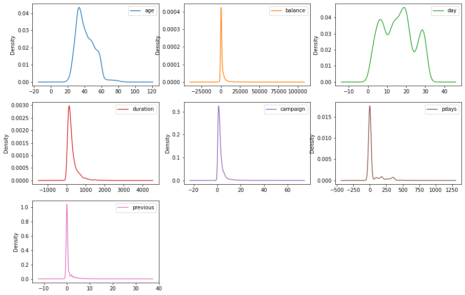

```python
df.plot(figsize=(15,10), kind='density', subplots=True, layout=(3,3), sharex=False);
```

**Density Plots:**  
With the excpetion of age, and day (which we saw in the descriptive statistics), all of the other variables show high concentrations of values around the mean, and significant outliers. These will be examined later to see how they should be treated in the dataset.

One plot we can look at with a little more detail, **age**.

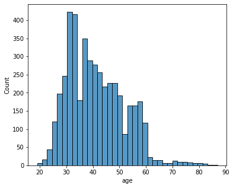

```python
plt.figure(figsize=(6,5))
sns.histplot(x='age', data=df);
```

**Age:** The age distribution shows a right skewed distribution with more values falling into the younger ages.

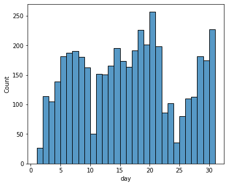

```python
plt.figure(figsize=(6,5))
sns.histplot(x='day', data=df, bins=30);
```

**Age:** There is a slight multi-modal distribution with three peaks around the 7th day, the 20th day and the 30th.

### Outlier Analysis

https://machinelearningmastery.com/how-to-use-statistics-to-identify-outliers-in-data/

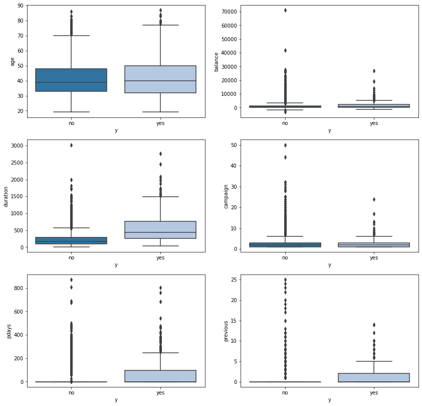

```python
# using seaborn library, plot each individually
fig, axes = plt.subplots(3, 2, figsize=(14,14))

ax = sns.boxplot(x="y", y="age", data=df, ax=axes[0, 0], palette='tab20')
ax = sns.boxplot(x="y", y="balance", data=df, ax=axes[0, 1], palette='tab20')
ax = sns.boxplot(x="y", y="duration", data=df, ax=axes[1, 0], palette='tab20')
ax = sns.boxplot(x="y", y="campaign", data=df, ax=axes[1, 1], palette='tab20')
ax = sns.boxplot(x="y", y="pdays", data=df, ax=axes[2, 0], palette='tab20')
ax = sns.boxplot(x="y", y="previous", data=df, ax=axes[2, 1], palette='tab20')
```

**Note**: Plotting `Boxplots` for each of the non-categorical values shows that each of the values does have a significant amout of outliers displayed. Let's see how many are present.

Using a method of counting outliers that fall outside of `+/- 3` standard deviations mean that we are accounting for `99.7%` of all data in this data set.

```python
# Function to print the number of outliers in a column.
def get_outliers(outl):
    '''Function to identify the number of outliers +/- 3 standar deviations outside of mean.
    Pass this function a Pandas Series (column)'''
    print('Series Name:', outl.name)
    # calculate summary statistics
    data_mean, data_std = np.mean(outl), np.std(outl)
    # identify outliers
    cut_off = data_std * 3
    lower, upper = data_mean - cut_off, data_mean + cut_off
    # identify outliers
    outliers = [x for x in outl if x < lower or x > upper]
    print('Identified outliers: %d' % len(outliers))
    # remove outliers
    outliers_removed = [x for x in outl if x >= lower and x <= upper]
    print('Non-outlier observations: %d' % len(outliers_removed))
    print()
```

```python
get_outliers(df['age'])
get_outliers(df['balance'])
get_outliers(df['duration'])
get_outliers(df['campaign'])
get_outliers(df['pdays'])
get_outliers(df['previous'])
```

```
Series Name: age
Identified outliers: 44
Non-outlier observations: 4477

Series Name: balance
Identified outliers: 88
Non-outlier observations: 4433

Series Name: duration
Identified outliers: 88
Non-outlier observations: 4433

Series Name: campaign
Identified outliers: 87
Non-outlier observations: 4434

Series Name: pdays
Identified outliers: 171
Non-outlier observations: 4350

Series Name: previous
Identified outliers: 99
Non-outlier observations: 4422
```

```python
# out_list = ['age', 'balance', 'day', 'duration', 'campaign', 'pdays', 'previous']

# from scipy import stats
# #  & (df[['y']] == "no")
# df = df[((np.abs(stats.zscore(df[out_list])) < 3)).all(axis=1)]
```

**Note**: *This is opposed to removing them before train-test split. The values might be useful in the overal predictions.*

### Multivariate Plots

Starting with Pair-wise plots to see if there are any obvious relationships in the data.

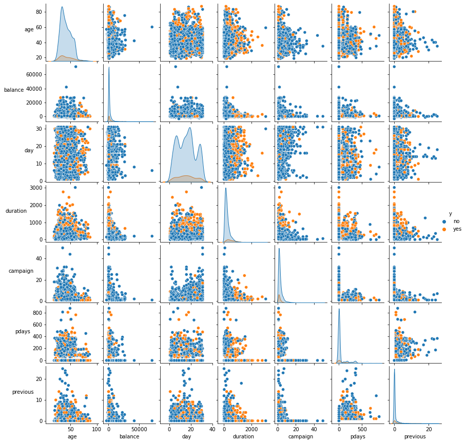

```python
# Using seaborn, pairwise plot by y

g=sns.pairplot(df, diag_kind = 'auto', hue="y")
g.fig.set_size_inches(12,12);

# rotate labels
for ax in g.axes.flatten():
    # rotate y axis labels
    ax.set_ylabel(ax.get_ylabel(), rotation = 0)
    # set y labels alignment
    ax.yaxis.get_label().set_horizontalalignment('right')
```

**Observations:**

Upon comparing all numeric variables against each other, it's not clear if there are any obvious relationships between variables (positive or negative correlations). We can test this next to be sure.

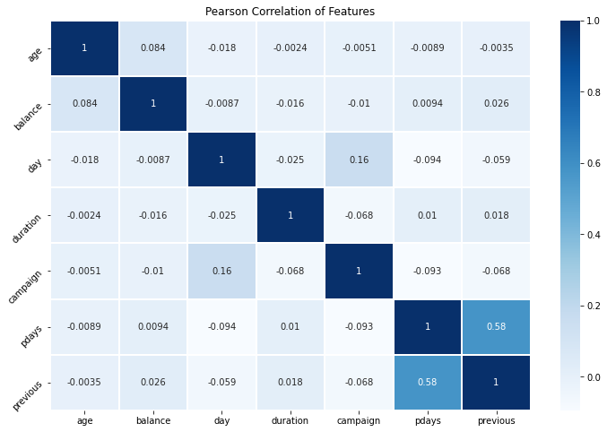

```python
# using seaboarn to plot correlation heat map
corr = df.corr()

f, ax = plt.subplots(figsize=(12, 8))

sns.heatmap(corr, cmap="Blues", annot=True, square=False, ax=ax,  linewidth = 1)
plt.title('Pearson Correlation of Features')
plt.yticks(rotation=45);
```

**Observations:**  
After running a Pearson's Correlation on the numeric values, there is not a strong corrrelation between variables. The strongest is `previous` vs. `pdays` at `0.58`. As a reminder `previous` is the number of contacts to the customer in prior marketing campaigns, and `pdays` is the number of days since last contact in this campaign.

### Demographic Plots

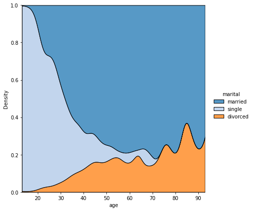

```python
sns.displot(data=df, x="age", hue="marital", kind="kde",
            height=6, multiple="fill", clip=(0, None), palette="tab20");
```

**Age / Marital Status:** When plotting `Marital` status over age on a density estimate plot, the `single` population tends to be younger, as expected, with `married` growing in population. `Divorced` also grows with age but is a smaller proportion of the total.

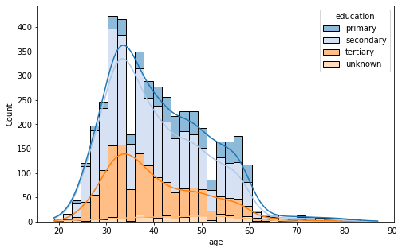

```python
plt.figure(figsize=(8,5))
sns.histplot(x='age', data=df, hue='education', multiple='stack', palette="tab20", kde=True);
```

**Age/Education:** There are relativley few people in the dataset that have an `unknown` education level, The rest of the values are somewhat evenly distributed across ages, with `secondary` school being the largest proportion.

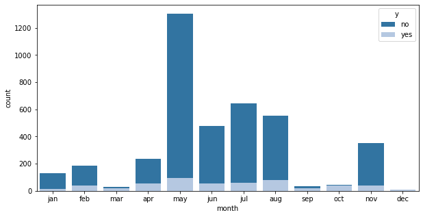

```python
months = ['jan', 'feb', 'mar', 'apr', 'may', 'jun', 'jul', 'aug', 'sep', 'oct', 'nov', 'dec']
plt.figure(figsize=(10,5))
sns.countplot(x='month', data=df, hue='y', palette="tab20", order=months, dodge=False);
```

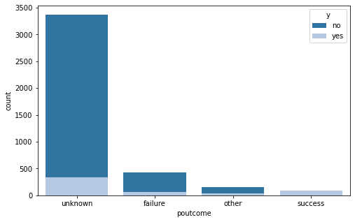

```python
plt.figure(figsize=(8,5))
sns.countplot(x='poutcome', data=df, hue='y', palette="tab20", dodge=False);
```

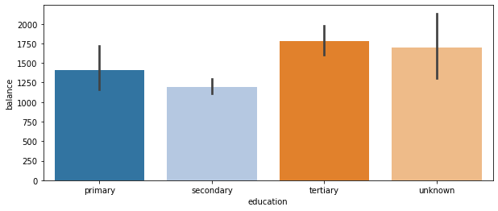

```python
plt.figure(figsize=(10,4))
ax = sns.barplot(x="education", y="balance", data=df, palette="tab20")
```

**Eduacation/Balance:** People with `unknown` and `tertiary` levels of education tend to have slightly higher savings. Those with secondary tend to have the lowest balance.

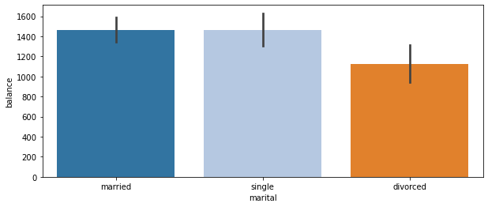

```python
plt.figure(figsize=(10,4))
ax = sns.barplot(x="marital", y="balance", data=df, palette="tab20")
```

**Marital/Balance:** `Single` and `Married` people have a similar mean `balance`. People who are `divorced` tend to have a lower balance.

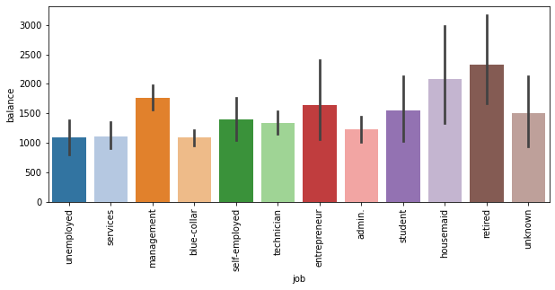

```python
plt.figure(figsize=(10,4))
ax = sns.barplot(x="job", y="balance", data=df, palette="tab20")
ax.set_xticklabels(ax.get_xticklabels(), rotation=90);
```

**Job/Balance:** Across the various jobs, `housemade` and `retired` are the leading savers. On the other spectrum, `blue-collar`, `services` and `unemployed` have the lowest.

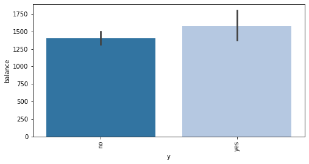

```python
plt.figure(figsize=(8,4))
ax = sns.barplot(x="y", y="balance", data=df, palette="tab20")
ax.set_xticklabels(ax.get_xticklabels(), rotation=90);
```

**Job/Balance:** Those with a higher average balance are slightly more likely to convert to the loan product.

## Create Prediction Model:

**Desired Outcome**: Create a model that will predict if the client will subscribe (yes/no) a term deposit (variable `y`) Assess model performance

### Feature Selection

**Chi-Squared Feature Selection**

Pearson’s chi-squared statistical hypothesis test is an example of a test for independence between categorical variables.

The results of this test can be used for feature selection, where those features that are independent of the target variable can be removed from the dataset.

The scikit-learn machine library provides an implementation of the chi-squared test in the chi2() function. This function can be used in a feature selection strategy, such as selecting the top k most relevant features (largest values) via the SelectKBest class.

For example, we can define the SelectKBest class to use the chi2() function and select all features, then transform the train and test sets.

https://machinelearningmastery.com/feature-selection-with-categorical-data/

We have a DataFrame with only the categorical data from our EDA, we'll use that to perform this analysis.

```python
cat_data.head()
```

|  | job | marital | education | default | housing | loan | contact | month | poutcome | y |
| --- | --- | --- | --- | --- | --- | --- | --- | --- | --- | --- |
| 0 | unemployed | married | primary | no | no | no | cellular | oct | unknown | no |
| 1 | services | married | secondary | no | yes | yes | cellular | may | failure | no |
| 2 | management | single | tertiary | no | yes | no | cellular | apr | failure | no |
| 3 | management | married | tertiary | no | yes | yes | unknown | jun | unknown | no |
| 4 | blue-collar | married | secondary | no | yes | no | unknown | may | unknown | no |

```python
X = cat_data.iloc[:, :-1].values
y = cat_data.iloc[:,-1].values
```

```python
oe = OrdinalEncoder(handle_unknown='ignore')
oe.fit(X)
X = oe.transform(X)
```

```python
# split into train and test sets
X_train, X_test, y_train, y_test = train_test_split(X, y, test_size=0.33, random_state=1)
```

```python
fs = SelectKBest(score_func=chi2, k='all')
fs.fit(X_train, y_train)
X_train_fs = fs.transform(X_train)
X_test_fs = fs.transform(X_test)
```

```
* job: 11.679248
* marital: 0.248626
* education: 3.339391
* default: 0.039239
* housing: 11.788867
* loan: 12.889637
* contact: 64.864792
* month: 4.102635
* poutcome: 10.921719
```

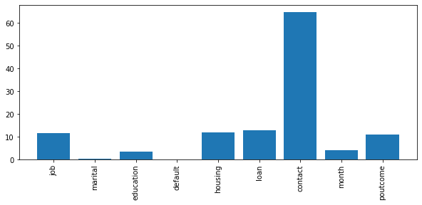

```python
# what are scores for the features
names = []
values = []
for i in range(len(fs.scores_)):
    print('* %s: %f' % (cat_data.columns[i], fs.scores_[i]))
    names.append(cat_data.columns[i])
    values.append(fs.scores_[i])
print()
chi_list = zip(names, values)
# plot the scores
plt.figure(figsize=(10,4))
plt.bar(names, values)
plt.xticks(rotation = 90)
plt.show()
```

**Results:** Based on the bar plot, we can see that `contact` has the strongest contribution followed by `job`, `housing`, `loan`, and `poutcome`. We can take these into consideration when building the model, but we can also try to see the prediction with all variables.

#### Dropping Columns

> **duration:** last contact duration, in seconds (numeric). Important note: this attribute highly affects the output target (e.g., if duration=0 then y='no'). Yet, the duration is not known before a call is performed. Also, after the end of the call y is obviously known. Thus, this input should only be included for benchmark purposes and should be discarded if the intention is to have a realistic predictive model.

```python
list(df.select_dtypes(include=['object']).columns)
```

```
['job',
 'marital',
 'education',
 'default',
 'housing',
 'loan',
 'contact',
 'month',
 'poutcome',
 'y']
```

```python
list(df.select_dtypes(include=['int64']).columns)
```

```
['age', 'balance', 'day', 'duration', 'campaign', 'pdays', 'previous']
```

```python
cat_list = ['job', 'education', 'housing', 'loan', 'contact', 'poutcome']
numeric_list = ['age', 'balance', 'day', 'campaign', 'pdays', 'previous']
```

**Note:** These two lists will be used subsequently to determine which numeric and categorical columns will be retained.

### Variable Encoding and Feature Scaling

**Feature Scaling:** Models trained on both Scaled and un-Scaled data were run. Depending on the final algorithm choice, this may or may not be needed. It will be included for the purposes of evaluating our models:

> **Which Algorithms may not benefit after Scaling?**  
> Some algorithms are independent of Scaling. Entropy & Information Gain based techniques are not sensitive to monotonic transformation. Tree-Based Algorithms, *Decision Tree, Random Forest, Boosted Trees(GBM, light GBM, xgboost)* may not benefit from scaling.

https://towardsdatascience.com/transformation-scaling-of-numeric-features-intuition-7f4436e8e074

```python
X = df.iloc[:, :-1]
y = df.iloc[:,-1]
y = y.values
```

```python
print('X: original:', X.shape)
```

```
X: original: (4521, 16)
```

```python
# define the data preparation for the columns
t = [('cat', OneHotEncoder(handle_unknown='ignore', sparse=False), cat_list),
     ('num', StandardScaler(), numeric_list)]
col_transform = ColumnTransformer(transformers=t)
```

```python
# Show the ColumnTransformer in action with the two steps
X = col_transform.fit_transform(X)
X
```

```
array([[ 0.        ,  0.        ,  0.        , ..., -0.57682947,
        -0.4072183 , -0.32041282],
       [ 0.        ,  0.        ,  0.        , ..., -0.57682947,
         2.98904408,  2.04173372],
       [ 0.        ,  0.        ,  0.        , ..., -0.57682947,
         2.89914302,  0.27012381],
       ...,
       [ 0.        ,  0.        ,  0.        , ...,  2.63916021,
        -0.4072183 , -0.32041282],
       [ 0.        ,  1.        ,  0.        , ...,  0.38796743,
         1.71045119,  1.45119709],
       [ 0.        ,  0.        ,  1.        , ..., -0.2552305 ,
         2.09003345,  3.81334363]])
```

```python
print('X: one-hot-encoded:', X.shape)
```

```
X: one-hot-encoded: (4521, 33)
```

**One Hot Encoding:** After encoding the features as binary `1/0` values for each, we can see that the number of columns as expanded from `16` to `33`. This increases the dimensionality of the dataset, but make handling the categorical variables consistent and represented by a numeric value.

**Label Encoding for Outcome Variable:** Finally the predicted variable `y` needs to be encoded with the label encoder.

```python
enc = LabelEncoder()
enc.fit(y)
y = enc.transform(y)
```

### Model Selection

Run the reduced feature set across a number of different models, and find the one with the best score.

The process will start by reducing the our X-independent variables down to the selected `12` features from the above process. This way we do not have to do feature selection again for each algorithm but can run a number of them to determine best performance. A number of classifiers will be used and the best one will be selected.

https://scikit-learn.org/stable/auto_examples/classification/plot_classifier_comparison.html

```
CPU times: user 88.3 ms, sys: 110 ms, total: 198 ms
Wall time: 1.74 s
* LogReg Precision = 0.184 StdDev = (0.016)

CPU times: user 44.6 ms, sys: 9.09 ms, total: 53.7 ms
Wall time: 539 ms
* DTree Precision = 0.219 StdDev = (0.048)

CPU times: user 62.5 ms, sys: 8.19 ms, total: 70.7 ms
Wall time: 3.93 s
* RandForest Precision = 0.411 StdDev = (0.086)

CPU times: user 64.5 ms, sys: 48 ms, total: 112 ms
Wall time: 4.27 s
* Extra Precision = 0.333 StdDev = (0.066)

CPU times: user 77.7 ms, sys: 82.3 ms, total: 160 ms
Wall time: 6.99 s
* GradBoost Precision = 0.381 StdDev = (0.080)

CPU times: user 60.8 ms, sys: 10.2 ms, total: 71 ms
Wall time: 1.84 s
* AdaBoost Precision = 0.266 StdDev = (0.040)

CPU times: user 65.4 ms, sys: 9.42 ms, total: 74.9 ms
Wall time: 458 ms
* SGD Precision = 0.186 StdDev = (0.037)

CPU times: user 56.6 ms, sys: 25.6 ms, total: 82.2 ms
Wall time: 783 ms
* NN Precision = 0.197 StdDev = (0.030)

CPU times: user 69.8 ms, sys: 105 ms, total: 175 ms
Wall time: 1.42 s
* Perceptron Precision = 0.147 StdDev = (0.030)
```

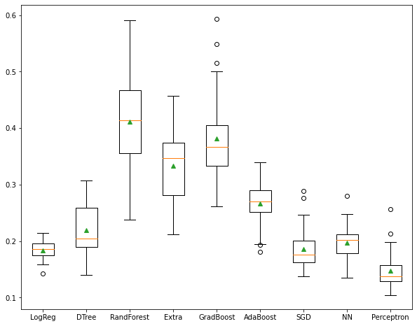

```python
# get a list of models to evaluate
def get_models():
    models = dict()
    over = SMOTE(random_state=42)
    under = RandomUnderSampler(random_state=42)

    # Decision Tree
    models['LogReg'] = Pipeline([('over', over), ('under', under), ('model', LogisticRegression(random_state=42))])
    models['DTree'] = Pipeline([('over', over), ('under', under), ('model', DecisionTreeClassifier(random_state=42))])
    models['RandForest'] = Pipeline([('over', over), ('under', under), ('model', RandomForestClassifier(random_state=42))])
    models['Extra'] = Pipeline([('over', over), ('under', under), ('model', ExtraTreesClassifier(random_state=42))])
    models['GradBoost'] = Pipeline([('over', over), ('under', under), ('model', GradientBoostingClassifier(random_state=42))])
    models['AdaBoost'] = Pipeline([('over', over), ('under', under), ('model', AdaBoostClassifier(random_state=42))])
    models['SGD'] = Pipeline([('over', over), ('under', under), ('model', SGDClassifier(random_state=42))])
    models['NN'] = Pipeline([('over', over), ('under', under), ('model', KNeighborsClassifier(3))])
    models['Perceptron'] = Pipeline([('over', over), ('under', under), ('model', Perceptron(random_state=42))])
    return models

# evaluate a give model using cross-validation
def evaluate_model(model, X, y):
    cv = RepeatedStratifiedKFold(n_splits=10, n_repeats=3, random_state=1)
    scores = cross_val_score(model, X, y, scoring='precision', cv=cv, n_jobs=-1)
    return scores

# get the models to evaluate
models = get_models()

# evaluate the models and store results
results, names = list(), list()
for name, model in models.items():
    %time scores = evaluate_model(model, X, y)
    results.append(scores)
    names.append(name)
    print('* %s Precision = %.3f StdDev = (%.3f)' % (name, np.mean(scores), np.std(scores)), '\n')

# plot model performance for comparison
plt.figure(figsize=(10,8))
plt.boxplot(results, labels=names, showmeans=True)
plt.show()
```

**Conclusion for Model:**  
The `RandomForestClassifier` algorithm peformed with regard to `precision` and will be the model we use for our prediction.

### Model Building

Next, apply the correct transformations to build the model. First start by splitting the dataset.

```python
# Split the dataset into Train and Test sets
X_train, X_test, y_train, y_test = train_test_split(X, y,
                                                    test_size=0.33, random_state=42)
```

```python
print("Training Size:", len(X_train))
print("Test Size:",len(y_train))
```

```
Training Size: 3029
Test Size: 3029
```

### Adjusting for Outliers

> The expectation is that the outliers are causing the model to learn a bias or skewed understanding of the problem, and that removing these outliers from the training set will allow a more effective model to be learned. We can achieve this by defining the LocalOutlierFactor model and using it to make a prediction on the training dataset, marking each row in the training dataset as normal (1) or an outlier (-1).

https://machinelearningmastery.com/how-to-use-statistics-to-identify-outliers-in-data/

```python
# identify outliers in the training dataset
# lof = LocalOutlierFactor()
# yhat = lof.fit_predict(X_train)
```

```python
# train_before = len(X_train)
# mask = yhat != -1
# X_train, y_train = X_train[mask, :], y_train[mask]

# summarize the shape of the updated training dataset
# train_after = len(X_train)
# print("Training Size:", train_after)
# print("Test Size:",len(X_test))
# print()
# print("Number of Outliers Removed:", train_before - train_after)
```

**Note:** Aproximately `30` outliers were removed using the `LocalOutlierFactor` method. However, the results were lower (`precision` for `1` prediction) with them removed. This includes when oversampling and oversampling with undersampling together.

### Adjusting for Imbalanced Data

> Imbalanced classification involves developing predictive models on classification datasets that have a severe class imbalance. The challenge is that most ML techniques will ignore, and in turn have poor performance on, the minority class, although typically it is performance on the minority class that is most important. There are various approaches to handling unbalanced datasets. One approach is Synthetic Minority Oversampling Technique (SMOTE). Here new examples are synthesized from the existing examples. This is a type of data augmentation for the minority class referred to as the *Synthetic Minority Oversampling Technique*, or **SMOTE** for short.

https://machinelearningmastery.com/smote-oversampling-for-imbalanced-classification/

https://imbalanced-learn.org/stable/

### Model Fitting & Training

```python
over = SMOTE(random_state=42)
under = RandomUnderSampler(random_state=42)
model = RandomForestClassifier(random_state=42)
```

```python
pipeline = Pipeline([('over', over), ('under', under), ('model', model)])
pipeline.fit_resample(X_train, y_train)
pipeline.fit(X_train, y_train)
```

```
Pipeline(steps=[('over', SMOTE(random_state=42)),
                ('under', RandomUnderSampler(random_state=42)),
                ('model', RandomForestClassifier(random_state=42))])
```

```python
y_pred = model.predict(X_test)
```

### Classification Report & Confusion Matrix

```
              precision    recall  f1-score   support

           0      0.914     0.969     0.941      1334
           1      0.474     0.234     0.314       158

    accuracy                          0.891      1492
   macro avg      0.694     0.602     0.627      1492
weighted avg      0.868     0.891     0.875      1492
```

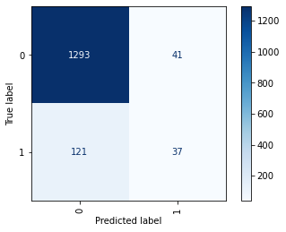

```python
# print accuracy report
print(classification_report(y_test, y_pred, digits=3))

# show confusion matrix
plot_confusion_matrix(model, X_test, y_test,
                      xticks_rotation='vertical',
                      cmap=plt.cm.Blues)
plt.show()
```

**Results:** After Adjusting for Imbalaced data with `SMOTE` the `RandomForestClassifier` performed with a precision of `0.474` for the value of `1`, or those customers that subscribed to a term deposit.

### ROC AUC

ROC curve (receiver operating characteristic curve) is a plot that summarizes the performance of a binary classification model on the positive class. It's a popular diagnostic tool for classifiers on balanced and imbalanced binary prediction problems as it's not biased to the majority or minority class. is a plot of False Positive Rate (x-axis) vs True Positive Rate (y-axis) for a number of different candidate threshold values between 0.0 and 1.0. The true positive rate is referred to as the sensitivity or the recall.

- **X-axis**: False Positive Rate=FP/(FP+TN)
- **Y-axis**: True Positive Rate=TP/(TP+FN)

Plot the ROC curve and choose a threshold that gives a desirable balance between the false positives and false negatives. Ideally, we want the fraction of correct positive class predictions to be 1 (top of the plot) and the fraction of incorrect negative class predictions to be 0 (left of the plot).

The best possible classifier achieving perfect result is the top-left at coordinate: (0,1) the threshold is applied to the probability cut-off point between the positive and negative classes (by default set at 0.5, halfway between each (0 and 1)

https://machinelearningmastery.com/roc-curves-and-precision-recall-curves-for-imbalanced-classification/

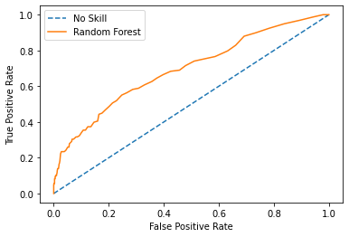

```python
yhat = model.predict_proba(X_test) # predict only probability of 1.
pos_probs = yhat [:, 1] # probabilities for just the positive class

# plot no skill roc curve
plt.plot([0, 1], [0, 1], linestyle='--', label='No Skill')

fpr, tpr, _ = roc_curve(y_test, pos_probs) # calculate roc curve for model

# plot model roc curve
plt.plot(fpr, tpr, label='Random Forest')
plt.xlabel('False Positive Rate')
plt.ylabel('True Positive Rate')
plt.legend()
plt.show()
```

Next we can calculate the actual ROC AUC Score

```python
# no skill model, stratified random class predictions
np.random.seed(1)
m = DummyClassifier(strategy='stratified', random_state=42)
m.fit(X_train, y_train)
no_skill_yhat = m.predict_proba(y_test)
no_skill_roc_auc = roc_auc_score(y_test, no_skill_yhat[:, 1])
print(f'No Skill ROC AUC {round(no_skill_roc_auc, 3)}')

# skilled model
roc_auc = roc_auc_score(y_test, pos_probs)
print(f'Random Forest ROC AUC {round(roc_auc, 4)}')
```

```
No Skill ROC AUC 0.492
Random Forest ROC AUC 0.6939
```

**Score:** The score for the model is `0.6939`.

### Precision-Recall

Precision-Recall Curves and AUC

Precision is a metric that quantifies the number of correct positive predictions made. It is calculated as the number of true positives divided by the total number of true positives and false positives.

- **Precision** = TruePositives / (TruePositives + FalsePositives)

The result is a value between 0.0 for no precision and 1.0 for full or perfect precision. Recall is a metric that quantifies the number of correct positive predictions made out of all positive predictions that could have been made. It is calculated as the number of true positives divided by the total number of true positives and false negatives (e.g. it is the true positive rate).

- **Recall** = TruePositives / (TruePositives + FalseNegatives)

The result is a value between 0.0 for no recall and 1.0 for full or perfect recall. Both the precision and the recall are focused on the positive class (the minority class) and are unconcerned with the true negatives (majority class). A precision-recall curve (or PR Curve) is a plot of the precision (y-axis) and the recall (x-axis) for different probability thresholds.

- **PR Curve:** Plot of Recall (x) vs Precision (y).

A model with perfect skill is depicted as a point at a coordinate of (1,1). A skillful model is represented by a curve that bows towards a coordinate of (1,1). A no-skill classifier will be a horizontal line on the plot with a precision that is proportional to the number of positive examples in the dataset. For a balanced dataset this will be 0.5.

The focus of the PR curve on the minority class makes it an effective diagnostic for imbalanced binary classification models.

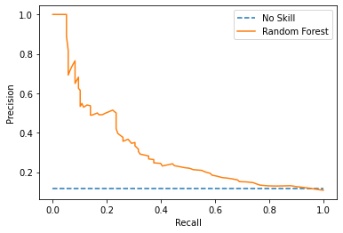

```python
# calculate the baseline as the proportion of the positive class
no_skill = len(y[y==1]) / len(y)

# plot the no skill precision-recall curve
plt.plot([0, 1], [no_skill, no_skill], linestyle='--', label='No Skill')

# calculate model precision-recall curve
precision, recall, _ = precision_recall_curve(y_test, pos_probs)

# plot the model precision-recall curve
plt.plot(recall, precision, label='Random Forest')
plt.xlabel('Recall')
plt.ylabel('Precision')
plt.legend()
plt.show()
```

```python
# no skill model, stratified random class predictions
precision, recall, _ = precision_recall_curve(y_test, no_skill_yhat[:, 1])
auc_score = auc(recall, precision)
print(f'No Skill PR AUC: {round(auc_score, 3)}')

# skilled model
precision, recall, _ = precision_recall_curve( y_test, pos_probs)
auc_score = auc(recall, precision)
print(f'Random Forest PR AUC: {round(auc_score, 4)}')
```

```
No Skill PR AUC: 0.147
Random Forest PR AUC: 0.3061
```

**Precision-Recall:**

Our final PR AUC Score of `0.3061`.

## Conclusion

In summary, this was a fascinating exercise. I started with exploring the data as I would a simpler dataset where you were looking for highly correlated variables and starting to make assessments from them. When viewing the data via `pairplots` and `Pearson's Correlation Matrix`, it was evident that these traditional methods or approaches to the data wouldn't apply. I explored and learned a few things:

- **Encoding Categorical Values:** Knowing that I needed to encode categorical values, I started with a function that I was familiar with from the prior exercise, the `LabelEncoder` method. I went down a long path until I read that this is not an appropriate method for encoding your input variables and only the Output variables. I switched then to `OneHotEncoding`. This was a good lesson and exercise.
- **Feature Selection:** For this process, I found an article on [Recursive Feature Elimination](https://machinelearningmastery.com/rfe-feature-selection-in-python/), which appeared to be a valuable method. I applied a method that iteratively tested all features from `2-17` in the dataset and selected the best one. I ended up not using this direction in favor of the [Chi-Squared](https://machinelearningmastery.com/feature-selection-with-categorical-data/) test for categorical feature selection. I was able to implement this and removed a number of low ranking features without saccrificing too much accuracy. I could have left everything in, but for the sake of learning, this was a good exercise.
- **Imbalanced Data**: Before applying `SMOTE` to the dataset and balancing it, my Output variable for a converted loan subscription was performing very low. About `~0.10` for the `1` response even though it was at `~0.90` for the `0` response. After applying to balance, this performed much better overall with my final model around `0.474`. A great article on this from [Towards Data Science](https://towardsdatascience.com/class-imbalance-random-sampling-and-data-augmentation-with-imbalanced-learn-63f3a92ef04a).
- **Outlier Handling**: I also attempted to use a new technique called [LocalOutlierFactor](https://scikit-learn.org/stable/modules/generated/sklearn.neighbors.LocalOutlierFactor.html) that calculated outliers in the training dataset. Approximately `~30` outliers were removed but the accuracy scores dropped as well, so I ended up not using this.
- **Model Selection:** This was the most straightforward after performing pre-processing. I iterated through multiple classifiers until I selected the best one. Not all performed equally, so it was good to see the variation in the results.
- **Model Evaluation:** With AUR-ROC and Precision-Recall being new, I read and learned a lot about how this helps give you less biased evaluation metrics since they deal with only those responses True Positive and False Positive.

**Bonus 1**  
One more area that I experimented on is the development of `Pipelines` in **Sklearn**. A pipeline takes both the pre-processing steps, such as `OneHotEncoding` and `SMOTE` and the `model.` It puts them into a singular pipeline that can be used to create a repeatable process around, such as deploying those pipelines into production on another machine. While I ended up using pipelines in my final process above, I also re-created the entire flow below. The final step is to save the pipeline to a pickled file for portability via [Model Persistence from Sklearn](https://scikit-learn.org/stable/modules/model_persistence.html).

**Bonus 2**  
This dataset was from Kaggle as a competition a few years ago. While I did *not* use any of that information to develop my solution, I did end up running my model on the `test.csv` dataset provided for the competition. My results were not that strong, leading me to believe that I could train a better model (or potentially some error in my workflow). This process was a good exercise since I was able to try the model on newly acquired data. My final score of `0.55` for ROC AUC was lower than the `0.6939` I acheived in my train-test.

## Bonus: Pipeline

Basic overview of ColumTransformer and Pipelines.  
https://www.dataschool.io/encoding-categorical-features-in-python/

Using the IMBLearn Pipeline to integrate SMOTE https://openscoring.io/blog/2020/10/24/converting_sklearn_imblearn_pipeline_pmml/

```python
X = df.iloc[:, :-1]
y = df.iloc[:,-1]
```

```python
cat_list = ['job', 'education', 'housing', 'loan', 'contact', 'poutcome']
```

```python
numeric_list = ['age', 'balance', 'day', 'campaign', 'pdays', 'previous']
```

```python
# Encode the y labels again for model-fitting purposes.  This must be done outside the pipeline,
enc = LabelEncoder()
enc.fit(y)
y = enc.transform(y)
```

```python
# define the data preparation for the columns
t = [('cat', OneHotEncoder(handle_unknown='ignore', sparse=False), cat_list), ('num', StandardScaler(), numeric_list)]
col_transform = ColumnTransformer(transformers=t)
# Oversampling
over = SMOTE(random_state=42)
# Undersample
under = RandomUnderSampler(random_state=42)
# Create Model
model = RandomForestClassifier(random_state=42)
```

```python
# Show the ColumnTransformer in action with the two steps
X_test = col_transform.fit_transform(X)
X_test
```

```
array([[ 0.        ,  0.        ,  0.        , ..., -0.57682947,
        -0.4072183 , -0.32041282],
       [ 0.        ,  0.        ,  0.        , ..., -0.57682947,
         2.98904408,  2.04173372],
       [ 0.        ,  0.        ,  0.        , ..., -0.57682947,
         2.89914302,  0.27012381],
       ...,
       [ 0.        ,  0.        ,  0.        , ...,  2.63916021,
        -0.4072183 , -0.32041282],
       [ 0.        ,  1.        ,  0.        , ...,  0.38796743,
         1.71045119,  1.45119709],
       [ 0.        ,  0.        ,  1.        , ..., -0.2552305 ,
         2.09003345,  3.81334363]])
```

```python
X_test.shape
```

```
(4521, 33)
```

```python
# Build the Pipleline using IMBLearn
pipe = Pipeline([
    ("col_trans", col_transform),
    ("smote", over),
    ("under", under),
    ("model", model)
])
```

```python
pipe.fit_resample(X, y)
```

```python
pipe.fit(X, y)
```

```
Pipeline(steps=[('col_trans',
                 ColumnTransformer(transformers=[('cat',
                                                  OneHotEncoder(handle_unknown='ignore',
                                                                sparse=False),
                                                  ['job', 'education',
                                                   'housing', 'loan', 'contact',
                                                   'poutcome']),
                                                 ('num', StandardScaler(),
                                                  ['age', 'balance', 'day',
                                                   'campaign', 'pdays',
                                                   'previous'])])),
                ('smote', SMOTE(random_state=42)),
                ('under', RandomUnderSampler(random_state=42)),
                ('model', RandomForestClassifier(random_state=42))])
```

```python
cv = RepeatedStratifiedKFold(n_splits=10, n_repeats=3, random_state=1)
scores = cross_val_score(pipe, X, y, scoring='precision', cv=cv, n_jobs=-1)
```

```python
print('* Mean Precision: %.3f and Standard Deviation: (%.3f)' % (np.mean(scores), np.std(scores)))
```

```
* Mean Precision: 0.428 and Standard Deviation: (0.092)
```

```python
dump(pipe, 'bank.joblib')
```

```
['bank.joblib']
```

## Bonus: Kaggle

The following is an attempt to run the `test` set from the Kaggle competition. The process uses the pipeline from above to run predictions on the supplied data set.

https://www.kaggle.com/c/bank-marketing-uci/leaderboard

```python
ka = pd.read_csv("test.csv")
ka2 = ka.copy()
ka.drop(columns=['Id'], inplace=True)
```

```python
# Load the model from the Pickle
pipe = load('bank.joblib')
```

```python
X_ka = ka.values
X_ka.shape
```

```
(427, 16)
```

**Pipeline:** Next, use the pipeline to predict the values from Kaggle

```python
y_ka_pred = pipe.predict(ka)
y_ka_pred
```

```
array([0, 0, 0, 0, 0, 0, 0, 0, 0, 0, 0, 0, 0, 0, 0, 0, 0, 0, 0, 0, 0, 0,
       0, 0, 0, 0, 0, 0, 0, 0, 0, 0, 0, 0, 0, 0, 0, 0, 0, 0, 0, 0, 0, 0,
       0, 0, 0, 0, 0, 0, 0, 0, 0, 0, 0, 0, 0, 0, 0, 0, 0, 1, 0, 0, 0, 0,
       0, 0, 0, 0, 0, 0, 0, 0, 0, 0, 0, 0, 0, 0, 0, 1, 0, 0, 0, 0, 0, 0,
       0, 0, 0, 0, 0, 0, 0, 0, 0, 0, 0, 0, 0, 0, 0, 0, 0, 0, 0, 0, 0, 0,
       0, 0, 0, 0, 0, 0, 0, 0, 0, 0, 0, 0, 0, 0, 0, 0, 0, 0, 0, 0, 0, 0,
       0, 0, 0, 0, 0, 0, 0, 0, 0, 0, 0, 0, 0, 0, 0, 0, 0, 0, 0, 0, 0, 0,
       0, 0, 0, 0, 0, 0, 0, 0, 0, 0, 0, 0, 0, 0, 0, 0, 0, 0, 0, 0, 0, 0,
       0, 0, 0, 0, 0, 0, 0, 0, 0, 0, 0, 0, 0, 0, 0, 0, 0, 0, 0, 0, 0, 0,
       0, 0, 0, 0, 0, 0, 0, 0, 0, 0, 0, 0, 0, 0, 0, 1, 0, 0, 0, 0, 0, 0,
       0, 0, 0, 0, 0, 0, 0, 0, 0, 0, 0, 0, 0, 0, 0, 0, 0, 0, 0, 0, 0, 0,
       0, 0, 0, 0, 0, 0, 0, 0, 0, 0, 0, 0, 0, 0, 0, 0, 0, 0, 0, 0, 0, 0,
       0, 0, 0, 0, 0, 0, 0, 0, 0, 0, 0, 0, 0, 0, 0, 0, 0, 0, 0, 0, 0, 0,
       0, 0, 0, 0, 0, 0, 0, 0, 0, 0, 0, 0, 0, 0, 0, 0, 0, 0, 0, 0, 0, 0,
       0, 0, 0, 0, 0, 0, 0, 0, 0, 0, 0, 0, 0, 0, 0, 0, 0, 0, 0, 0, 0, 0,
       0, 0, 0, 0, 0, 0, 0, 0, 0, 0, 0, 0, 0, 0, 0, 0, 0, 0, 0, 0, 0, 0,
       0, 0, 0, 0, 0, 0, 0, 0, 0, 0, 0, 0, 0, 0, 0, 0, 0, 0, 0, 0, 0, 0,
       0, 0, 0, 0, 0, 0, 0, 1, 0, 0, 0, 0, 0, 0, 0, 0, 0, 0, 0, 0, 0, 0,
       0, 0, 0, 0, 1, 0, 0, 0, 0, 0, 0, 0, 0, 0, 0, 1, 0, 0, 0, 0, 0, 0,
       0, 0, 0, 1, 0, 0, 0, 0, 0])
```

```python
y_ka_pred.sum()
```

```
7
```

```python
new_ka = pd.DataFrame({'Id' : ka2['Id'], 'y': y_ka_pred})
```

```python
new_ka.to_csv("broepke.csv", index=False)
```

**Results:**  
The Kaggle scoring system returned a result of `0.55` for ROC AUC score which is just better than the no-skill `0.5` point. I honestly would have thought these result would have been better, given the train-test results. There must be some sort of error in my logic, but the process is close!

[figure not shown]